# Coding Assignment 1

CS598: Practical Statistical Learning

Naomi Bhagat - nbhagat3

Michael Miller - msmill3

Joe May - jemay3

08 September 2023

# Assignment Data

Program: MCS-DS  
Team contributions:

| Person | Contribution |
| --- | --- |
| Naomi Bhagat | Part 1-1, 1-2, 1-3, 2-1, 2-2, 2-3, 3-1 |
| Michael Miller | Part 4-1, 4-2, 5 |
| Joe May | Part 1-1, 1-2, 1-3, 2-1, 2-2, 2-3, 3-1, 3-2 |

# Part 1: Generate Data

## Part 1-1

First generate the 20 centers from two-dimensional normal. You can use any mean and covariance structure. You should not regenerate the centers. Use these 20 centers throughout this simulation study.

```r
# Set Seed
set.seed(5245)

# import necessary libraries
library(class)

csize = 10
p = 2
s_centers = 1
s_x = 1
#s_x = sqrt(1/2);

m1 = matrix(rnorm(csize*p), csize, p)*s_centers + cbind( rep(1.0,csize), rep(1.0,csize) )
m0 = matrix(rnorm(csize*p), csize, p)*s_centers + cbind( rep(-1.0,csize), rep(-1.0,csize) )
```

## Part 1-2

Given the 20 centers, generate a training sample of size 200 (100 from each class) and a test sample of size 10,000 (5,000 from each class).

```r
# Training sample of size 200
n = 100
id1 = sample(1:csize, n, replace=TRUE)
id0 = sample(1:csize, n, replace=TRUE)
traindata = matrix(rnorm(2*n*p), 2*n, p)*s_x + rbind(m1[id1,], m0[id0,])
dim(traindata)
```

```
## [1] 200   2
```

```r
Ytrain = rep(c(1, 0), each = n)

# Test sample of size 10,000

N = 5000
# Allocate the n samples for class 1  to the 10 clusters
id1 = sample(1:csize, N, replace=TRUE)
# Allocate the n samples for class 1 to the 10 clusters
id0 = sample(1:csize, N, replace=TRUE)
testdata = matrix(rnorm(2*N*p), 2*N, p)*s_x + rbind(m1[id1,], m0[id0,])
dim(testdata)
```

```
## [1] 10000     2
```

```r
Ytest = rep(c(1, 0), each = N)
```

## Part 1-3

[figure not shown]

```r
plot(traindata[,1], traindata[,2], type="n", xlab="", ylab="")
points(traindata[1:n,1], traindata[1:n,2], col="green")
points(traindata[(n+1):(2*n),1], traindata[(n+1):(2*n),2], col="red")
points(m1[1:csize,1], m1[1:csize,2], pch="+", cex=1.5, col="green")
points(m0[1:csize,1], m0[1:csize,2], pch="+", cex=1.5, col="red");
legend("bottomright", pch = c(1,1), col = c("red", "green"), legend = c("class 1", "class 0"))
```

# Part 2: kNN

1. Implement kNN from scratch; use Euclidean Distance. Your implementation should meet the following requirements:
- Input: Your kNN function should accept three input parameters: training data, test data, and k. No need to write your kNN function to handle any general input; it suffices to write a function that is able to handle the data for this specific simulation study: binary classification; features are two-dimensional numerical vectors.
- Output: Your function should return a vector of predictions for the test data.
- Vectorization: Efficiently compute distances between all test points and training points simultaneously. Make predictions for all test points in a single operation.
- No Loops: Do not use explicit loops like for or while inside your kNN function to compute distances or make predictions. Instead, harness the power of vectorized operations for efficient computations. For example, you can use broadcasting in Numpy or command outer in R.

```r
# Euclidean helper function
euclidean_distance = function(point1, point2) {
  if (length(point1) == length(point2)) {
    return(sqrt(sum((point1 - point2)^2)))
  } else {
    stop('Vectors must be of the same length')
  }
}



knn_from_scratch = function(train, test, truth, k) {

  expanded_test_data = matrix(rep(test,each = nrow(train)), ncol=2)
  expanded_train_data = matrix(rep(t(train), times = nrow(test)), ncol=2, byrow = TRUE)
  # Repeat test rows to subtract from corresponding training rows

  train_less_test = expanded_train_data - expanded_test_data
  train_less_test_sum_squares = rowSums(train_less_test^2)
  neighbor_distances = matrix(sqrt(train_less_test_sum_squares),nrow=nrow(test), byrow=TRUE)
  # Take the sum of squares of the difference between test points from training points
  # Uses vector functionality to calculate each point's distance to neighbors

  nearest_neighbor_address = function(j) {
    nearest_unique = head(sort(unique(j)),k)

    get_nearest_indexes <- function(num) {
      tie_index=which(j %in% num)
      if(length(tie_index) > 1) {
        return_idx = sample(tie_index,1)
      } else {
        return_idx = tie_index
      }
      return(return_idx)
    }

    nearest_neighbors = sapply(nearest_unique, get_nearest_indexes)
    return(nearest_neighbors)
  }
  # Function to get k nearest neighbors (temp variable j for k)

  neighborhood_votes = apply(neighbor_distances, 1, nearest_neighbor_address)
  # Return address of each row's nearest neighbor

  neighborhood_votes_v = matrix(truth[neighborhood_votes], nrow=nrow(test), byrow=TRUE)
  # Collect votes from nearest neighbor

  determine_winner = function(point){
    if (sum(point) > k/2) {
      return(1)
    } else if (sum(point) < k/2) {
      return(0)
    } else {
      return(sample(0:1, 1))
    }
  }
  # Determine winner given votes of k nearest neighbors. Ties are broken randomly.

  predictions = apply(neighborhood_votes_v, 1, determine_winner)
  return(predictions)
}
```

2. Explain how you handle distance ties and voting ties; distance ties may occur when you have multiple (training) observations that are equidistant from a test observation. voting ties may occur when K is an even number and you have 50% of the k-nearest-neighbors from each of the two classes.

**If there are distance ties when determining nearest neighbors, one of the equidistant neighbors is selected at random for voting.**

**If the number of votes for each point is the same, we have decided to randomly generate a class for that particular test point because the two classes at that point are equally as likely.**

3. Test your code with the training/test data you just generated when K = 1, 3, 5; and compare your results with knn in R or sklearn.neighbors in Python. Report your results (on the test data) as a 2-by-2 table (confusion matrix) for each K value. Report the results from knn or sklearn.neighbors as a 2-by-2 table (confusion matrix) for each K value

```r
# k = 1
print("k = 1")
```

```
## [1] "k = 1"
```

```r
baseline_test.pred = knn(traindata, testdata, Ytrain, k=1)
table(Ytest, baseline_test.pred)
```

```
##      baseline_test.pred
## Ytest    0    1
##     0 3790 1210
##     1 1219 3781
```

```r
implementation_test.pred = knn_from_scratch(traindata, testdata, Ytrain, k=1)
table(Ytest, implementation_test.pred)
```

```
##      implementation_test.pred
## Ytest    0    1
##     0 3790 1210
##     1 1219 3781
```

```r
# k = 3
print("k = 3")
```

```
## [1] "k = 3"
```

```r
baseline_test.pred = knn(traindata, testdata, Ytrain, k=3)
table(Ytest, baseline_test.pred)
```

```
##      baseline_test.pred
## Ytest    0    1
##     0 3961 1039
##     1 1184 3816
```

```r
implementation_test.pred = knn_from_scratch(traindata, testdata, Ytrain, k=3)
table(Ytest, implementation_test.pred)
```

```
##      implementation_test.pred
## Ytest    0    1
##     0 3961 1039
##     1 1184 3816
```

```r
# k = 5
print("k = 5")
```

```
## [1] "k = 5"
```

```r
baseline_test.pred = knn(traindata, testdata, Ytrain, k=5)
table(Ytest, baseline_test.pred)
```

```
##      baseline_test.pred
## Ytest    0    1
##     0 3994 1006
##     1 1242 3758
```

```r
implementation_test.pred = knn_from_scratch(traindata, testdata, Ytrain, k=5)
table(Ytest, implementation_test.pred)
```

```
##      implementation_test.pred
## Ytest    0    1
##     0 3994 1006
##     1 1242 3758
```

# Part 3: cvkNN

## Part 3-1

Implement KNN classification with K chosen by 10-fold cross-validation from scratch.  
- Set the candidate K values from 1 to 180. (The maximum candidate K value is 180. Why?)  
- From now on, you are allowed to use the built-in kNN function from R or Python instead of your own implementation from Part 2.  
- It is possible that multiple K values give the (same) smallest CV error; when this happens, pick the largest K value among them, since the larger the K value, the simpler the model.

We choose 180 as the max K value because there will be 180 samples in our training dataset.

```r
get_best_k = function(x, y) {

  # init variables for looping through k values
  max_k = 180
  fold_count = 10
  k_values = 1:max_k
  average_errors = rep(0, max_k)
  fold_size = floor(nrow(x) / fold_count)
  random_idx = sample(1:nrow(x))

  # loop through values of k, for each, calculate n-fold cv error
  for (k in k_values){
    # cumulative error for averaging out at the end
      error = 0

    for (fold in 1:fold_count){
      # calculate the index for train/validate for this fold
      # do this by getting ordered idx (e.g. 1:10), then using that to get rand idx
      ordered_val_idx = ((fold - 1) * fold_size + 1) : (fold * fold_size)
      val_idx = random_idx[ordered_val_idx]

      # split data into train/val. Use negative index to exclude ones we don't want
      fold_train_x = x[-val_idx, ]
      fold_train_y = y[-val_idx]
      fold_val_x = x[val_idx, ]
      fold_val_y = y[val_idx]

      # Make prediction
      fold_predicted_y = knn(fold_train_x, fold_val_x, fold_train_y, k=k)

      # Sum the error
      error = error + sum(fold_predicted_y != fold_val_y)
    }

    # Add error to array to track
    average_errors[k] = error / fold_count
  }

  # uncomment to debug
  # plot(average_errors, xlab="k", ylab="Average error count", main="Error vs K")

  # Find lowest error (larger k breaks tie) which.max returns first, so reversing
  # array will get us last
  min_idx = length(average_errors) - which.min(rev(average_errors)) + 1
  min_error = average_errors[min_idx]
  best_k = k_values[min_idx]

return(best_k)
}
```

## Part 3-2

Test your code with the training/test data you just generated. Report your results (on the test data) as a 2-by-2 table and also report the value of the selected K.

```r
# now train model using our preferred k
best_k = get_best_k(traindata, Ytrain)
predicted = knn(traindata, testdata, Ytrain, k=best_k)
actual = Ytest
print(table(actual, predicted))
```

```
##       predicted
## actual    0    1
##      0 4425  575
##      1 1227 3773
```

```r
print(paste0("The value of the selected k is ", best_k))
```

```
## [1] "The value of the selected k is 94"
```

# Part 4: Bayes rule

Implement the Bayes rule. Your implementation should meet the following requirements: -Do not use explicit loops over the test sample size (10,000 or 5,000). -You are allowed to use loops over the number of centers (10 or 20), although you can avoid all loops.

```r
# now train model using our preferred k
bayes_rule = function(x, s, m1, m0) {
  # x = x values
  # s = sigma used to generate x
  # m0 = means of class 0 (for each center)
  # m1 - means of class 1 (for each center)

  # from assignment 1 (campuswire #36)

  # initialize variables for loop
  center_count = nrow(m1)
  numerator = rep(0, nrow(x))
  denominator  = rep(0, nrow(x))

  # iterate through centers, and sum for each
  for(center in 1:center_count){
    current_m1 = m1[center, ]
    current_m0 = m0[center, ]

    # get norm of each row
    m1_norm = apply(x - current_m1, 1, function(row) sqrt(sum(row^2)))
    m0_norm = apply(x - current_m0, 1, function(row) sqrt(sum(row^2)))

    # calculate numerator and denominator portions for each center
    denominator = denominator + exp(-m0_norm / (2 * s^2))
    numerator = numerator + exp(-m1_norm / (2 * s^2))

  }

  # return 1 if numerator is bigger else 0
  return(as.numeric(numerator >= denominator))
}
```

2. Test your code with the test data you just generated. (Note that you do not need training data for the Bayes rule.) Report your results (on the test data) as a 2-by-2 table.

```r
# get prediction, output to table
predicted = bayes_rule(testdata, s_x, m1, m0)
actual = Ytest
print(table(actual, predicted))
```

```
##       predicted
## actual    0    1
##      0 4470  530
##      1 1408 3592
```

# Part 5: Simluation Study

Given the 20 centers generated in Part 1, repeatedly generate 50 training/test datasets (training size = 200 and test size = 10,000). For each pair of training/test datasets, calculate the test errors (the averaged 0/1 loss on the test data set) for each of the following three procedures:

1. kNN with K = 7 (you can use the built-in kNN function from R or Python);
2. kNN with K chosen by 10-fold CV (your implementation from Part 3); and
3. the Bayes rule (your implementation from Part 4).

Present the test errors graphically, e.g., using a boxplot or strip chart (see below). Also, report the (min, max, median, 25% quantile, 75% quantile) for the 50 selected K values.

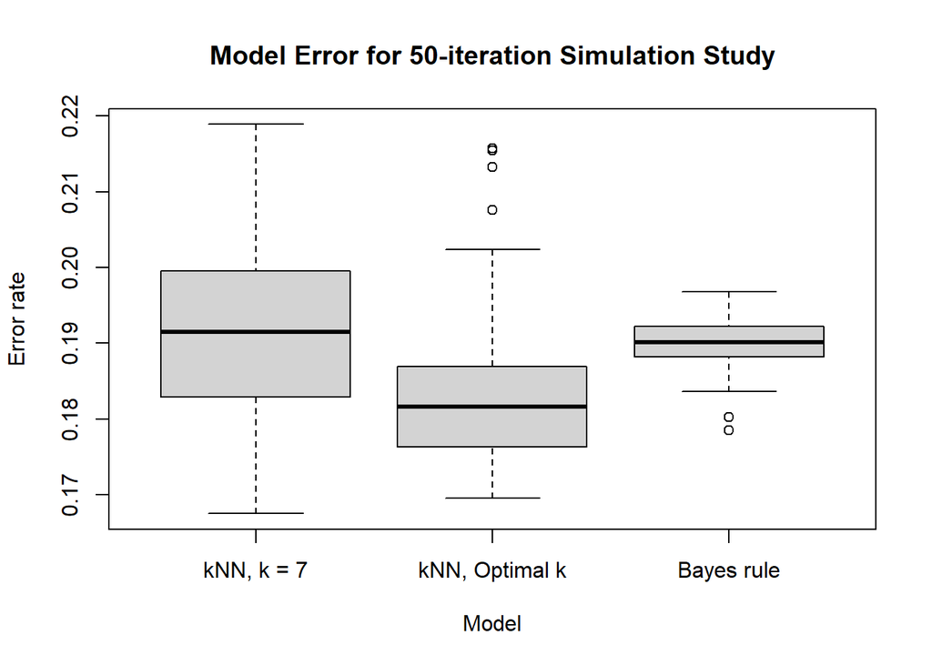

```r
# parameters for the simulation
n_sims = 50
n_train = 200
n_test = 10000

# initialize data collection
errors = matrix(0, nrow=n_sims, ncol=3)
best_ks = rep(0, n_sims)

# iterate, run each simulation
for (sim in 1:n_sims) {

  #####  generate data #####
  n = n_train/2
  id1 = sample(1:csize, n, replace=TRUE)
  id0 = sample(1:csize, n, replace=TRUE)
  train_x = matrix(rnorm(2*n*p), 2*n, p)*s_x + rbind(m1[id1,], m0[id0,])
  train_y = rep(c(1, 0), each = n)

  N = n_test/2
  # Allocate the n samples for class 1  to the 10 clusters
  id1 = sample(1:csize, N, replace=TRUE)
  # Allocate the n samples for class 1 to the 10 clusters
  id0 = sample(1:csize, N, replace=TRUE)
  test_x = matrix(rnorm(2*N*p), 2*N, p)*s_x + rbind(m1[id1,], m0[id0,])
  test_y = rep(c(1, 0), each = N)

  #####  run the models #####
  # knn with K  7
  predicted_y_knn7 = knn(train_x, test_x, train_y, k=7)

  # knn with best k
  best_k = get_best_k(train_x, train_y)
  predicted_y_knn_best = knn(train_x, test_x, train_y, k=best_k)

  # bayes
  predicted_y_bayes = bayes_rule(test_x, s_centers, m1, m0)

  #####  store output data #####
  errors[sim, 1] = sum(predicted_y_knn7 != test_y) / n_test
  errors[sim, 2] = sum(predicted_y_knn_best != test_y) / n_test
  errors[sim, 3] = sum(predicted_y_bayes != test_y) / n_test
  best_ks[sim] = best_k
}

boxplot(errors,
        main = 'Model Error for 50-iteration Simulation Study',
        xlab = 'Model',
        ylab = 'Error rate',
        names = c('kNN, k = 7', 'kNN, Optimal k', 'Bayes rule')
        )
```

## Statistics for optimal K-values

```r
print(summary(best_ks))
```

```
##    Min. 1st Qu.  Median    Mean 3rd Qu.    Max.
##    3.00   16.00   31.50   47.78   71.00  166.00
```